# Reproducible Research: Assignment 1

Ghida Ibrahim

4 May 2016

## Summary

This document analyzes 2 months long data about personal movement collected from the activity monitoring device of one person. The goal is to draw meaningful conclusions about the variability of the human movement across time, in weekdays Vs weekends as well as over different hours of the day.

## Reading and summarizing the Data

We start by reading and summarizing the data.

```r
activity <- read.csv("activity.csv")
summary(activity)
```

```
##      steps                date          interval
##  Min.   :  0.00   2012-10-01:  288   Min.   :   0.0
##  1st Qu.:  0.00   2012-10-02:  288   1st Qu.: 588.8
##  Median :  0.00   2012-10-03:  288   Median :1177.5
##  Mean   : 37.38   2012-10-04:  288   Mean   :1177.5
##  3rd Qu.: 12.00   2012-10-05:  288   3rd Qu.:1766.2
##  Max.   :806.00   2012-10-06:  288   Max.   :2355.0
##  NA's   :2304     (Other)   :15840
```

We notice that we have three variables: “steps” corresponding to the number of walked steps, “date” corresponding to given day and “interval” referring to a 5 minutes time Interval during a given day.

## Analyzing the total number of steps per day

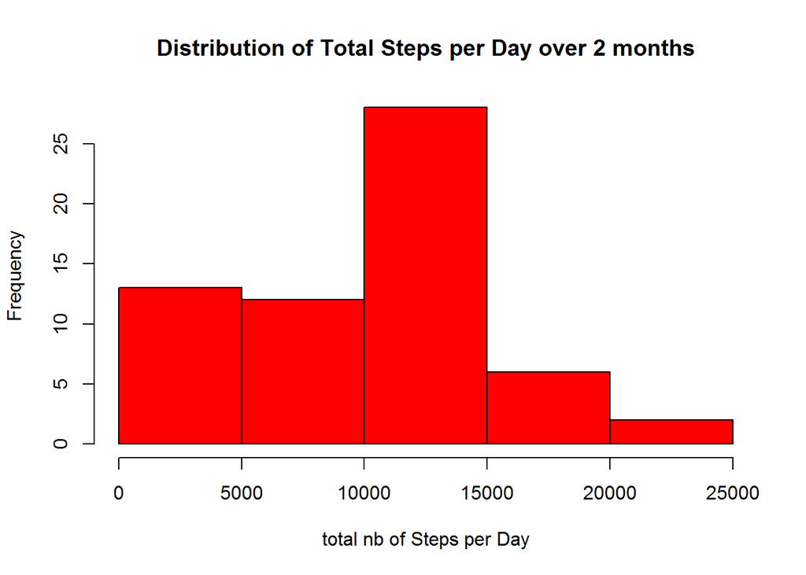

```r
SumSteps <- tapply(activity$steps,activity$date,sum,na.rm=TRUE)
hist(SumSteps,col="red",xlab="total nb of Steps per Day", main="Distribution of Total Steps per Day over 2 months")
```

```r
means <- mean(SumSteps)
median <- median(SumSteps)
```

We also calculate the mean and the median of the total number of steps taken each day. The mean of the total number of steps per day is: 9354.23 The median of the total number of steps per day is: 10395 We notice that the mean and the median have two different values and that the mean has a lesser value than the median. This is particularly due to the high number of NA values that were removed from the dataset.

## Analyzing Steps hourly distribution

Next, we consider the 5 minutes intervals that we have per day and we use the 2 months long data in order to calculate the average number of steps taken at each interval. We plot the daily distribution of the average number of steps per interval and we track the interval where the maximum number of steps are walked.

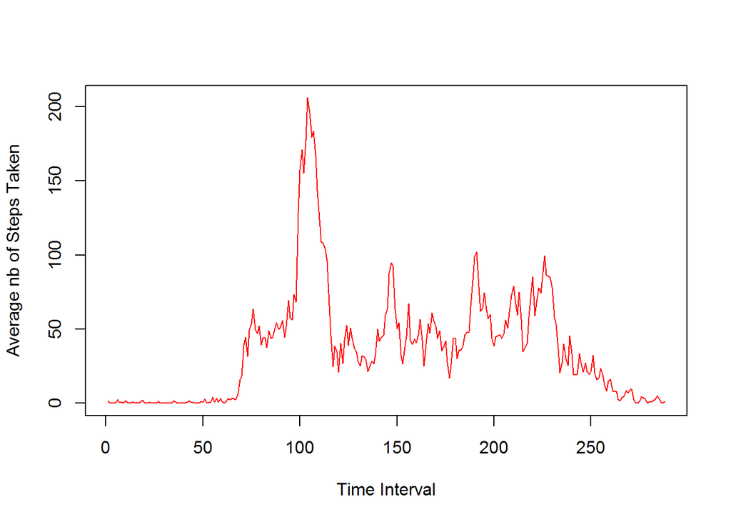

```r
AvgSteps <- tapply(activity$steps,activity$interval,mean,na.rm=TRUE)
n <- dim(AvgSteps)
plot(AvgSteps,xlab="Time Interval",ylab="Average nb of Steps Taken",type="l",col="red")
```

```r
index <- 0
for (i in 1:length(AvgSteps)) {if (AvgSteps[i] == max(AvgSteps)) index<-i}
```

The interval is 104. The corresponding time is around 8h40 am.

## Imputing Missing Data and analyzing consequences

Next is the R code that we used for imputing NA values in the dataset. The strategy that we use consists of replacing NA values in the “steps” variable with the previously calculated average steps value for the interval in question.

```r
naactivity <- subset(activity,is.na(activity$steps)==TRUE)
nrow(naactivity)
```

```
## [1] 2304
```

```r
for (i in 1:nrow(activity)) {if (is.na(activity$steps[i])==TRUE) {
  if (i%%n !=0)
  {activity$steps[i] <- AvgSteps[i %% n]}
  else {activity$steps[i] <- AvgSteps[n]}
 }
}
```

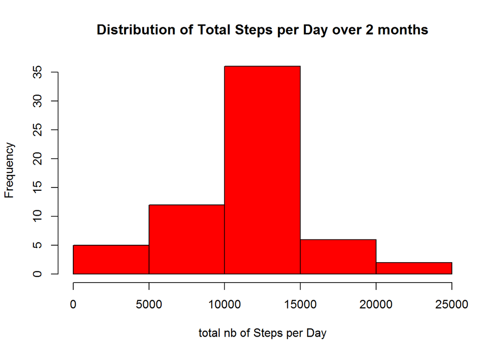

```r
SumSteps2 <- tapply(activity$steps,activity$date,sum)
hist(SumSteps2,col="red",xlab="total nb of Steps per Day", main="Distribution of Total Steps per Day over 2 months")
```

```r
means2 <- mean(SumSteps2)
median2 <- median(SumSteps2)
```

## Comparing Weekdays and Weekends walking activity

In this section, we create a new label variable “weekday” which indicates whether a given date is a weekday or a weekend. We then plot the daily distribution of the average number of steps per 5 minutes interval for a weeday and a weekend day, respectively.

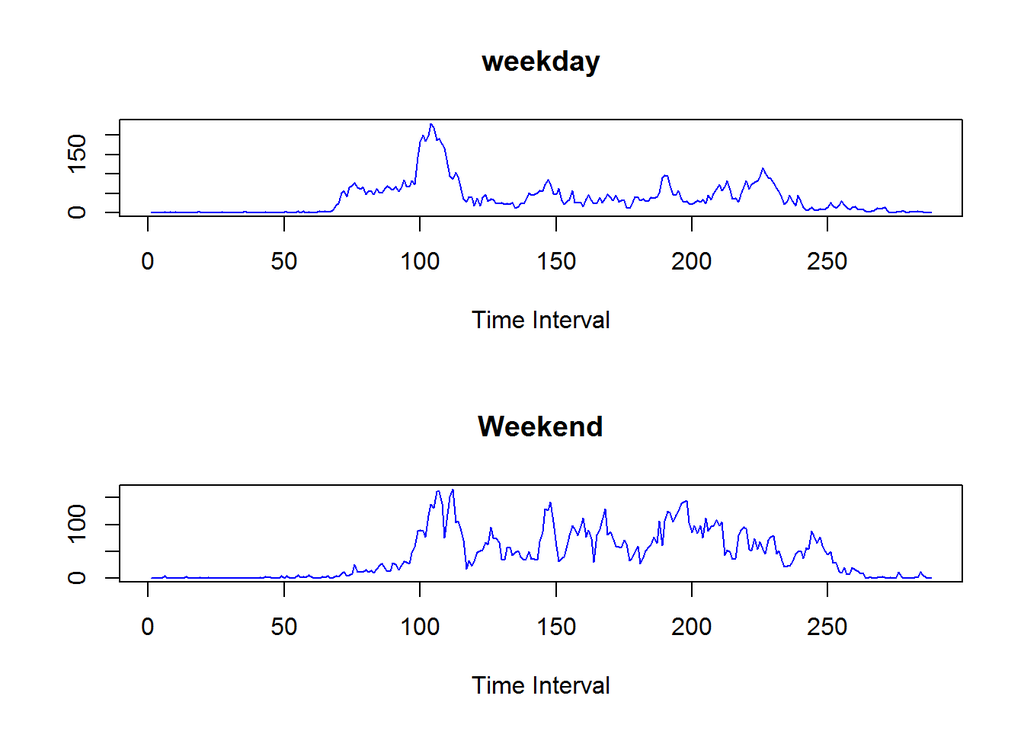

```r
activity$weekday <- weekdays(as.Date(activity$date))
for (i in 1:nrow(activity)) {
 if (activity$weekday[i] == "Saturday" || activity$weekday[i] == "Sunday") {activity$weekday[i] <- "weekend"}
  else {activity$weekday[i] <- "weekday"}
}
 weekdayAct <- subset(activity, activity$weekday =="weekday")
 weekendAct <- subset(activity, activity$weekday =="weekend")


AvgStepsWeekday <- tapply(weekdayAct$steps,weekdayAct$interval,mean)
AvgStepsWeekend <- tapply(weekendAct$steps,weekendAct$interval,mean)
par(mfrow=c(2,1))
plot(AvgStepsWeekday,xlab="Time Interval",ylab="",type="l",col="blue", main= "weekday")
plot(AvgStepsWeekend,xlab="Time Interval",ylab="",type="l",col="blue", main = "Weekend")
```

Based on plots, we witness more time intervals with a high number of steps walked in average during a weekend day than during a weekday. In particular, we observe peaks in walking activities in the morning (around 9 am), at noon time (around 12 am), in the afternoon (around 4 pm) and in the evening (around 8 pm) in a weekend day whereas these peaks are concentrated in the morning and the evening during a weekday.